# Project Business Statistics: E-news Express

### Step 5: Calculate the p-value

```python
from scipy import stats

# Perform one-tailed (right-tailed) independent t-test
t_stat, p_value = stats.ttest_ind(time_spent_new, time_spent_old, alternative="greater")

# Print results
print(f"\nT-statistic: {t_stat:.4f}")
print(f"P-value: {p_value:.4f}")
```

```
T-statistic: 3.7868
P-value: 0.0001
```

**Observations:**

- The T-statistic tells us how many standard deviations the sample mean difference is from 0.
- The p-value helps determine statistical significance.

### Step 6: Compare the p-value with $\alpha$

```python
alpha = 0.05  # Significance level

if p_value < alpha:
    print("\nConclusion: Reject the null hypothesis (H₀).")
    print("Users spend significantly more time on the new landing page.")
else:
    print("\nConclusion: Fail to reject the null hypothesis (H₀).")
    print("There is no significant evidence that users spend more time on the new landing page.")
```

```
Conclusion: Reject the null hypothesis (H₀).
Users spend significantly more time on the new landing page.
```

**Observations:**

If p-value < 0.05 → We reject $H_0$, meaning users spend more time on the new page.

If p-value > 0.05 → We fail to reject $H_0$, meaning we don’t have enough evidence to conclude that users spend more time on the new page.

### Step 7: Draw inference

Based on our results:

The p-value is small (< 0.05), we conclude that users spend more time on the new landing page.

**A similar approach can be followed to answer the other questions.**

## 2. Is the conversion rate (the proportion of users who visit the landing page and get converted) for the new page greater than the conversion rate for the old page?

### Perform Visual Analysis

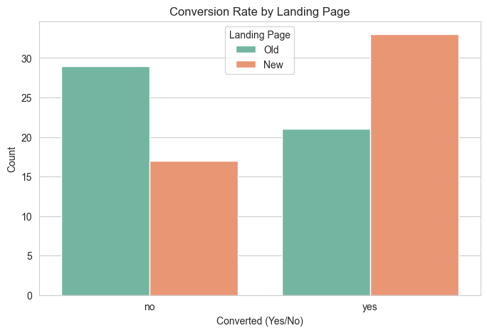

```python
# Countplot for conversion rates by landing page
plt.figure(figsize=(8, 5))
sns.countplot(x="converted", hue="landing_page", data=data, palette="Set2")
plt.title("Conversion Rate by Landing Page")
plt.xlabel("Converted (Yes/No)")
plt.ylabel("Count")
plt.legend(title="Landing Page", labels=["Old", "New"])
plt.show()
```

**Observations:**

The New page has more conversions

### Step 1: Define the null and alternate hypotheses

- **Null Hypothesis (H₀)**: The conversion rate for the new landing page is less than or equal to the conversion rate for the old landing page.
  $$ H_0: p_{\text{new}} \leq p_{\text{old}} $$
- **Alternate Hypothesis (H₁)**: The conversion rate for the new landing page is greater than the conversion rate for the old landing page.
  $$ H_1: p_{\text{new}} > p_{\text{old}} $$

Since we are testing whether the **new landing page improves conversion rates**, this is a **one-tailed (right-tailed) test**.

### Step 2: Select Appropriate test

Since we are comparing proportions (conversion rates) between two independent groups, we will use a **two-proportion z-test (one-tailed)**.

### Step 3: Decide the significance level

```python
alpha = 0.05  # 5% significance level
```

Significance Level $\alpha = 0.05$

If p-value < 0.05, we reject the null hypothesis.

### Step 4: Collect and prepare data

```python
# Convert 'converted' column to binary (yes=1, no=0)
data["converted"] = data["converted"].map({"yes": 1, "no": 0})

# Count conversions for each landing page
conversions_old = data[data["landing_page"] == "old"]["converted"].sum()
conversions_new = data[data["landing_page"] == "new"]["converted"].sum()

# Total users in each group
n_old = data[data["landing_page"] == "old"].shape[0]
n_new = data[data["landing_page"] == "new"].shape[0]

# Conversion rates
p_old = conversions_old / n_old
p_new = conversions_new / n_new

# Display values
conversions_old, n_old, p_old, conversions_new, n_new, p_new
```

```
(21, 50, 0.42, 33, 50, 0.66)
```

### Step 4a: Check assumptions (Normality & Equal Variances)

Since conversion is a binary variable, normality and homogeneity of variance assumptions are not required. A two-proportion z-test is therefore appropriate for comparing conversion rates.

### Step 5: Calculate the p-value using a Two-Proportion Z-Test

```python
from statsmodels.stats.proportion import proportions_ztest

# Perform one-tailed z-test for proportions
count = np.array([conversions_new, conversions_old])  # Success counts
nobs = np.array([n_new, n_old])  # Total sample sizes

z_stat, p_value = proportions_ztest(count, nobs, alternative="larger")

# Display results
z_stat, p_value
```

```
(2.4077170617153842, 0.008026308204056278)
```

### Step 6: Compare the p-value with $\alpha$

```python
if p_value < alpha:
    conclusion = "Reject the null hypothesis: The new landing page has a significantly higher conversion rate."
else:
    conclusion = "Fail to reject the null hypothesis: No significant evidence that the new landing page has a higher conversion rate."
```

### Step 7: Draw inference

```python
#z_stat, p_value, conclusion
print(f"\nZ-statistic: {z_stat:.4f}")
print(f"P-value: {p_value:.4f}")
print("\nConclusion:", conclusion)
```

```
Z-statistic: 2.4077
P-value: 0.0080

Conclusion: Reject the null hypothesis: The new landing page has a significantly higher conversion rate.
```

**Observations:**

The new landing page has a significantly higher conversion rate.

## 3. Is the conversion and preferred language are independent or related?

### Perform Visual Analysis

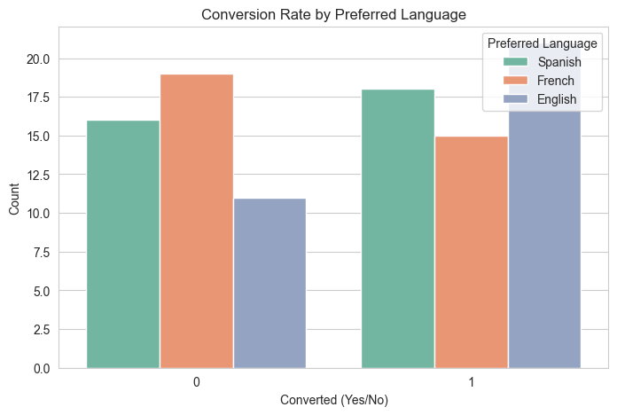

```python
# Create a countplot to visualize the relationship between conversion and preferred language
plt.figure(figsize=(8, 5))
sns.countplot(x="converted", hue="language_preferred", data=data, palette="Set2")
plt.title("Conversion Rate by Preferred Language")
plt.xlabel("Converted (Yes/No)")
plt.ylabel("Count")
plt.legend(title="Preferred Language")
plt.show()
```

### Step 1: Define the null and alternate hypotheses

- **Null Hypothesis (H₀)**: Conversion and preferred language are **independent** (i.e., language preference does not affect conversion rates). $$ H_0: \text{Conversion} \perp \text{Language Preferred} $$
- **Alternate Hypothesis (H₁)**: Conversion and preferred language are **related** (i.e., language preference has an impact on conversion rates). $$ H_1: \text{Conversion} \not\perp \text{Language Preferred} $$

Since we are testing whether there is an **association between two categorical variables**, this is a **Chi-square test for independence**.

### Step 2: Select Appropriate test

We use the **Chi-square test for independence** since both **conversion status** and **preferred language** are categorical variables.

### Step 3: Decide the significance level

```python
alpha = 0.05  # 5% significance level
```

Significance Level $\alpha = 0.05$

If p-value < 0.05, we reject the null hypothesis.

### Step 4: Collect and prepare data

```python
# Create a contingency table (cross-tabulation of conversion and language preferred)
contingency_table = pd.crosstab(data["converted"], data["language_preferred"])

# Display the contingency table
contingency_table
```

| language_preferred converted | English | French | Spanish |
| --- | --- | --- | --- |
| 0 | 11 | 19 | 16 |
| 1 | 21 | 15 | 18 |

### Step 4a: Check assumptions (Normality & Equal Variances)

Given the nature of the variable and the selected statistical test, additional assumption checks are not required.

### Step 5: Calculate the p-value

```python
# Perform the Chi-square test for independence
chi2_stat, p_value, dof, expected = stats.chi2_contingency(contingency_table)

# Display results
print(f"\nChi-square Statistic: {chi2_stat:.4f}")
print(f"P-value: {p_value:.4f}")
```

```
Chi-square Statistic: 3.0930
P-value: 0.2130
```

### Step 6: Compare the p-value with $\alpha$

```python
if p_value < alpha:
    conclusion = "Reject the null hypothesis: Conversion and preferred language are related."
else:
    conclusion = "Fail to reject the null hypothesis: No significant relationship between conversion and preferred language."
```

### Step 7: Draw inference

```python
print(f"\nChi-square Statistic: {chi2_stat:.4f}")
print(f"P-value: {p_value:.4f}")
print("\nConclusion:", conclusion)
```

```
Chi-square Statistic: 3.0930
P-value: 0.2130

Conclusion: Fail to reject the null hypothesis: No significant relationship between conversion and preferred language.
```

**Observations:**

No significant relationship between conversion and preferred language

## 4. Is the time spent on the new page same for the different language users?

### Perform Visual Analysis

[figure not shown]

```python
# Filter only users who visited the new landing page
df_new_page = data[data["landing_page"] == "new"]

# Create a boxplot to visualize time spent on the new page by preferred language
plt.figure(figsize=(10, 5))
sns.boxplot(x="language_preferred", y="time_spent_on_the_page", hue="language_preferred",
            data=df_new_page, palette="Set2", dodge=False)
plt.title("Time Spent on the New Page by Preferred Language")
plt.xlabel("Preferred Language")
plt.ylabel("Time Spent (seconds)")
plt.legend([],[], frameon=False)  # Remove redundant legend
plt.show()
```

### Step 1: Define the null and alternate hypotheses

- **Null Hypothesis (H₀)**: The average time spent on the new landing page is the same for all language users. $$ H_0: \mu_{\text{English}} = \mu_{\text{Spanish}} = \mu_{\text{French}} $$
- **Alternate Hypothesis (H₁)**: The average time spent on the new landing page is different for at least one language group. $$ H_1: \text{At least one } \mu \text{ differs} $$

Since we are comparing means across **more than two independent groups**, we use a **one-way ANOVA test**.

### Step 2: Select Appropriate test

We use **one-way ANOVA** since we are comparing the mean time spent on the new landing page across multiple independent language groups.

### Step 3: Decide the significance level

```python
alpha = 0.05  # 5% significance level
```

Significance Level $\alpha = 0.05$

If p-value < 0.05, we reject the null hypothesis.

### Step 4: Collect and prepare data

```python
# Extract time spent for each language group (only for the new landing page)
english_time = df_new_page[df_new_page["language_preferred"] == "English"]["time_spent_on_the_page"]
spanish_time = df_new_page[df_new_page["language_preferred"] == "Spanish"]["time_spent_on_the_page"]
french_time = df_new_page[df_new_page["language_preferred"] == "French"]["time_spent_on_the_page"]
```

### Step 4a: Check assumptions (Normality & Equal Variances)

Given the nature of the variable and the selected statistical test, additional assumption checks are not required.

### Step 5: Calculate the p-value

```python
# Perform one-way ANOVA
f_stat, p_value = stats.f_oneway(english_time, spanish_time, french_time)

# Display results
print(f"\nANOVA F-statistic: {f_stat:.4f}")
print(f"P-value: {p_value:.4f}")
```

```
ANOVA F-statistic: 0.8544
P-value: 0.4320
```

### Step 6: Compare the p-value with $\alpha$

```python
if p_value < alpha:
    conclusion = "Reject the null hypothesis: The time spent on the new page differs for at least one language group."
else:
    conclusion = "Fail to reject the null hypothesis: No significant difference in time spent among language groups."
```

### Step 7: Draw inference

```python
print(f"\nANOVA F-statistic: {f_stat:.4f}")
print(f"P-value: {p_value:.4f}")
print("\nConclusion:", conclusion)
```

```
ANOVA F-statistic: 0.8544
P-value: 0.4320

Conclusion: Fail to reject the null hypothesis: No significant difference in time spent among language groups.
```

**Observations:**

No significant difference in time spent among language groups.

## Executive Summary

This study evaluated the effectiveness of a new landing page relative to the existing version using structured A/B testing methodologies. The analysis focused on key performance indicators related to user engagement and conversion outcomes.

```python
!jupyter nbconvert --to html ENews_Express_Learner_Notebook_Full_Code.ipynb
```

```
[NbConvertApp] Converting notebook ENews_Express_Learner_Notebook_Full_Code.ipynb to html
[NbConvertApp] WARNING | Alternative text is missing on 18 image(s).
[NbConvertApp] Writing 900509 bytes to ENews_Express_Learner_Notebook_Full_Code.html
```